# IODS course project

## # **Exercise 5. Dimensionality reduction techniques**

```r
library("ggplot2")
library("GGally")
library("corrplot")
human <- read.table("http://s3.amazonaws.com/assets.datacamp.com/production/course_2218/datasets/human2.txt", sep  =",", header = T)
```

```r
str(human)
```

```
## 'data.frame':    155 obs. of  8 variables:
##  $ Edu2.FM  : num  1.007 0.997 0.983 0.989 0.969 ...
##  $ Labo.FM  : num  0.891 0.819 0.825 0.884 0.829 ...
##  $ Edu.Exp  : num  17.5 20.2 15.8 18.7 17.9 16.5 18.6 16.5 15.9 19.2 ...
##  $ Life.Exp : num  81.6 82.4 83 80.2 81.6 80.9 80.9 79.1 82 81.8 ...
##  $ GNI      : int  64992 42261 56431 44025 45435 43919 39568 52947 42155 32689 ...
##  $ Mat.Mor  : int  4 6 6 5 6 7 9 28 11 8 ...
##  $ Ado.Birth: num  7.8 12.1 1.9 5.1 6.2 3.8 8.2 31 14.5 25.3 ...
##  $ Parli.F  : num  39.6 30.5 28.5 38 36.9 36.9 19.9 19.4 28.2 31.4 ...
```

```r
summary(human)
```

```
##     Edu2.FM          Labo.FM          Edu.Exp         Life.Exp
##  Min.   :0.1717   Min.   :0.1857   Min.   : 5.40   Min.   :49.00
##  1st Qu.:0.7264   1st Qu.:0.5984   1st Qu.:11.25   1st Qu.:66.30
##  Median :0.9375   Median :0.7535   Median :13.50   Median :74.20
##  Mean   :0.8529   Mean   :0.7074   Mean   :13.18   Mean   :71.65
##  3rd Qu.:0.9968   3rd Qu.:0.8535   3rd Qu.:15.20   3rd Qu.:77.25
##  Max.   :1.4967   Max.   :1.0380   Max.   :20.20   Max.   :83.50
##       GNI            Mat.Mor         Ado.Birth         Parli.F
##  Min.   :   581   Min.   :   1.0   Min.   :  0.60   Min.   : 0.00
##  1st Qu.:  4198   1st Qu.:  11.5   1st Qu.: 12.65   1st Qu.:12.40
##  Median : 12040   Median :  49.0   Median : 33.60   Median :19.30
##  Mean   : 17628   Mean   : 149.1   Mean   : 47.16   Mean   :20.91
##  3rd Qu.: 24512   3rd Qu.: 190.0   3rd Qu.: 71.95   3rd Qu.:27.95
##  Max.   :123124   Max.   :1100.0   Max.   :204.80   Max.   :57.50
```

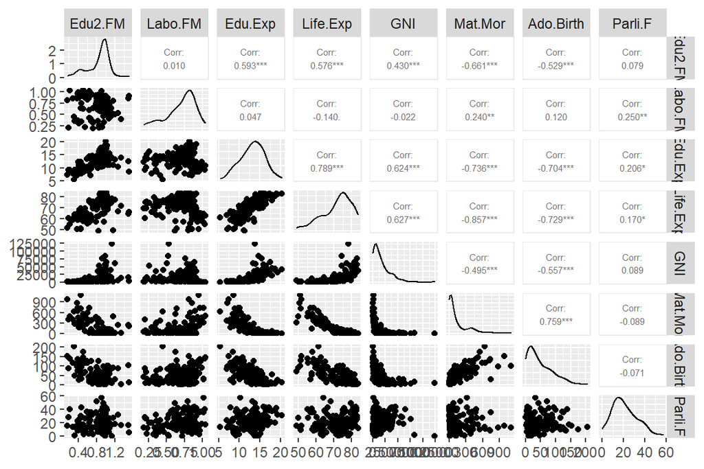

```r
ggpairs(human, upper = list(continuous = wrap('cor', size = 2)))
```

The variables are:

Edu2.FM: Ratio of females to males educated at secondary and higher education levels

Labo.FM: Ratio of females to males labour market participation rate (LFPR)

Edu.Exp: Expected years of schooling

Life.Exp: Life expectancy at birth (years)

GNI: Gross national income per capita (GNI)

Mat.Mor: Maternal mortality ratio (MMR) (deaths per 100 000 live births)

Ado.Birth: Adolescent birth rate (ABR) (births per 1 000 women ages 15-19)

Parli.F: Share of parliamentary seats held by women (% of seats)

We can see from the plot that the variables (some) are quite normally distributed. However, mat.mor and Ado.Birth are heavily tailed. Some of the variables have a strong correlation. For instance Maternal mortality ratio (Mat.Mor) is highly correlated with life expectancy at birth (Life.Exp), which is quite intuitive. Additionally, it seems like the higher the mothers’ mortal rate is the lower the expected education levels. Expected years of schooling and Life expectancy at birth are also very correlated.

Further information can be found in: http://hdr.undp.org/en/content/human-development-index-hdi